# Gov 50 Final Project

Zack Popiel

## Final Project

Introduction

When looking at the beginnings of a civil war, or the onset, one can assign specific types of rebellion warfare to each according to Kalyvas and Balcells’s (2010) analysis of rebellion. First is a symmetric nonconventional onset, where the rebellion force would have limited resources and development. Because of the nature of the state, the rebellion would involve itself in informal fighting with primitive technology on both sides. Next is a symmetric conventional onset in which the controlling state and the rebellion both possess similar power and engage in a very formal means of fighting. Here, the sides are also comparable and would engage in conventional warfare with modern weapons. Lastly, is the longest-lasting and most common of the rebellion types—irregular warfare—where the oppressive state has substantial power over the lesser-developed insurgency. These three types of civil war onset represent three configurations of power between regimes and opponents. In an analysis conducted by Kalyvas and Balcells (2010), the most frequent of these categorized rebellions is irregular warfare (54%) followed by conventional warfare (34%) and symmetric nonconventional warfare with 12%. What Kalyvas and Balcells (2010) note is that irregular warfare, although occurring more than half of the time, occurred less than anticipated as it was previously thought to be almost the standard of civil war onset.

When looking at Kalyvas and Balcells’s (2010) three types of civil war onset–-irregular, conventional, and symmetric non-conventional—there is no data to indicate how the introduction of social media and increased communication (since 2004) impacted the relative frequency of insurgencies. Because of a very different social media environment since the post-Cold War era (1991-2004), I predict we should see an increase in insurgencies. To test this theory, this paper will first look at how to categorize each civil war onset based on Kalyvas’s and Balcells’s (2010) study. Then it will examine civil war onsets that have occurred since 2004 and classify the conflicts into the three types of civil war onsets to determine whether they will be more or less frequent, or stay stagnant. Then test, with data, whether civil wars as a whole will increase since 2004. The paper then aims to proves that the relative frequency of irregular civil war onsets greatly increases, symmetrical nonconventional stays the same, and symmetric conventional decreases. I credit the uptick in irregular civil war onset to the utilization of social media for communication in insurgent efforts. Then, the paper shows a significant decrease in civil war onsets as a whole since the Post-Cold War era being especially violent.

Data

It is first important to recognize our data points, the 12 civil wars onsets since 2004. They are as follows: the First Central African Republic Civil War (2004-2007), the Chadian Civil War (2005-2010), the Iraqi Civil War (2006-2008), the First Libyan Civil War (2011), the Second Ivorian Civil War (2011), the South Sudanese Civil War (2013-2020), the Second Libyan Civil War (2014-2020), the Tigray War (2020-2022), the Myanmar Civil War (2021-Present), the Syrian Civil War (2011-Present), the Yemeni Civil War (2014-Present), and the Central African Republic Civil War (2012-Present). The onsets of these civil wars were classified using the descriptions of the types of civil war onset, based on the comprehensive news reports, journals, and documents that describe the onset. For example the descriptors for Irregular warfare: insurgency, paramilitary groups, factional fighting, assassinations, guerilla; for Symmetric Converntional: open confrontation, advanced weaponry, professional military forces, clear front line, regular forces; for Symmetric nonconvetional: primitive warfare, both sides’ use of IEDs, attacks on civilians, undveloped, impoversihed. Then I expand Kalyvas and Balcells’ (2010) categorizing of each civil war onset into new columns titled “Social Media Age (2004-2023)” in Figure 1. I also added a column to every period (1945-1990, 1991-2004, 2004-2023) to calculate the rate of onset, as the periods are not a uniform number of years. So the rate would show how often each onset would occur given consistent time periods. I also switched the “percentage” columns for each period with a column showing the “relative frequency” of each onset during each period compared to the other onsets, as that is the metric I am using to prove my hypotheses. After the columns were added I adjusted the last column (“Both Periods”) to “All Periods” to see cumulative results. This allowed me to calculate the annual onset rates of the three onsets and compare them to each period. Expanding this chart allowed me to test my hypotheses that the rate of irregular civil war onset will increase as symmetric conventional and symmetric nonconventional will stay stagnant in rate. Then, to address my final hypothesis that civil war onsets as a whole have increased since 2004, I continued Kalyvas and Balcells’ (2010) graph in Figure 2; specifically the “Wars Starting” line, as I am specifically looking at the onset. I continued the line graph until 2023, so the trend of civil war onset can be seen in conjunction with the previous periods. I looked at all three of the onsets classifications together because I hypothesized that the rate of irregular civil war onset would increase while symmetric conventional and symmetric nonconventional would stay the same—so cumulative onsets would increase.

When qualitatively classifying the 3 types of civil war onset, I found that 2 data points represented symmetric conventional, 2 represented symmetric nonconventional, and 8 represented irregular warfare. An example of symmetric non-conventional was the Second Ivorian Civil War. It was a military conflict between supporters of the acting President of Ivory Coast and supporters of the internationally recognized president-elect Alassane Ouattara. The conflict saw very limited military technology, with the culminating event being carried out via the personal cars of the soldiers on both sides. So there are clear examples of underdeveloped war tactics by both sides. An example of symmetric conventional is the Iraqi Civil War (2006-2008) which primarily involved two large military forces in the Iraqi government and various insurgent groups engaging in traditional warfare tactics, such as clashes, ambushes, and sieges with advanced equipment, a clear indication of symmetric conventional war. Lastly, an example of an irregular classification is Second Libyan Civil War (2014-2020). The Libyan National Army was a militia group backed by Nato and Western powers that fought against the technologically advanced Government of National Accord which was in power at the time. The conflict saw a militia group fighting a technologically advanced government. Guerilla warfare and assassination tactics were used. Again, all descriptors that describe irregular warfare. After the data points were classified, it was added to the expanded chart below (Figure 1).

Figure 1

```r
library(kableExtra)
```

```r
library(ggplot2)
civil_war_onset_table <- read.csv("Gov 50 Data Table - Sheet1.csv")
kable(civil_war_onset_table)
```

[output not shown]

Additionally, I address my second hypothesis that the relative frequency of civil war onset as a whole increased as a result of more frequent irregular warfare onsets and stagnant symmetric conventional and symmetric nonconventional onsets. In order to see if the relative frequency has increased, I added yearly data on civil war onset since 2004 to Kalyvas and Balcells’ (2010) data as seen below in Figure 2. Furthermore, the research design is cross-sectional because I am examining data from a specific time period (since 2004) and comparing the relative frequency across the 3 types of civil war onsets (irregular, symmetric conventional, and symmetric non-conventional) within that timeframe.

Figure 2

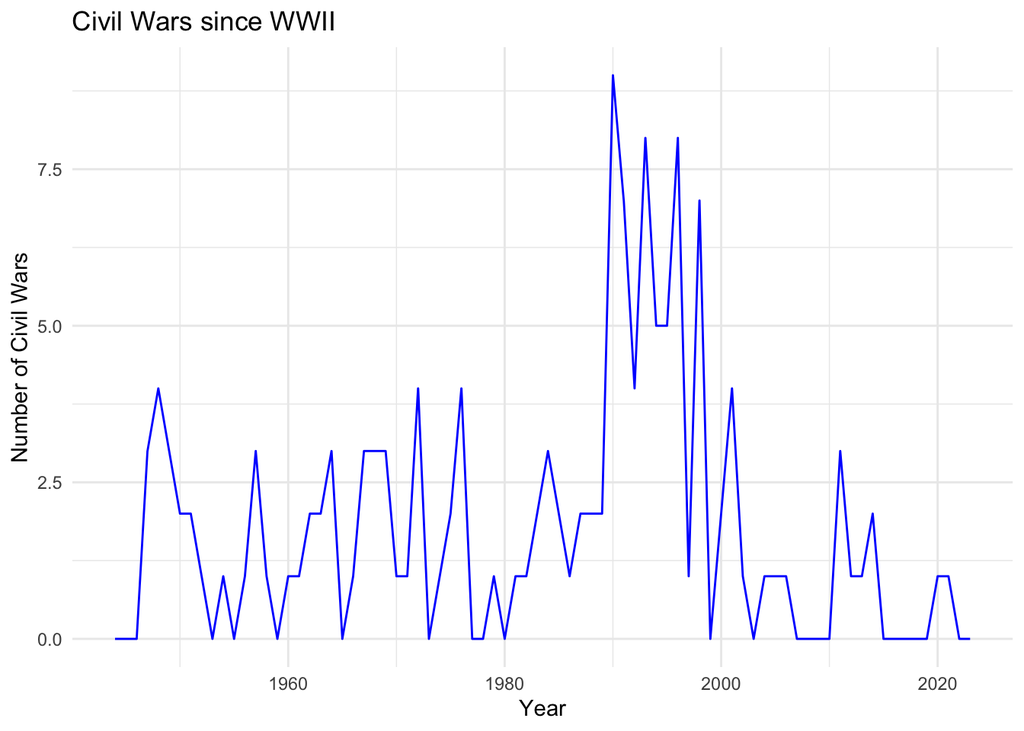

```r
library(ggplot2)

civil_war_onset<- read.csv("Gov 50 Data Set - Sheet1.csv")

ggplot(data = civil_war_onset, aes(x = Year, y = `Number.of.Civil.Wars`)) +
  geom_line(color = "blue") +
  labs(title = "Civil Wars since WWII", x = "Year", y = "Number of Civil Wars") +
  theme_minimal()
```

Results

In Figure 2, regarding my second thesis, if we were to be able to see a relative increase in civil war onset from the Post-Cold War period, we should see an increase in the number of civil wars starting. In other words, we should see a visual positive increase in the number of civil wars starting after 2004, which we do not. So my second hypothesis does not hold true. I would argue that the Post-Cold War era is the outlier as seen by Figure 1 and Figure 2 in the total rate of onsets per year. The Post-Cold War saw an average of 3.54 civil war onsets per year, compared to 2.20 from 1944-1990 and 0.63 from 2004-2023. There were many segments of the 1944-1990 period that look very similar to the 2004-2023 period, but not the 1991-2004 period. So, the Post-Cold War era was just especially violent.

Conclusion

Here is the link to the Kalyvas and Balcells journal with the data. https://www-jstor-org.ezp-prod1.hul.harvard.edu/stable/40863761?typeAccessWorkflow=login